# Effect of Additional Income and Expenses

Maggie Johnson

Here we explore the effect of purchased fertilizer on the difference in expenses/profit between the Boone and Thompson farms. Also of interest is the effect of the additional income (and likewise expenses) in the Thompson practices.

### With/Without Fertilizer Costs

The profit and losses from livestock on the Thompson farms are not included in the data. It is suggested that Thompson fertilized the fields using manure from his livestock, and subsequently has an expense due to spreading manure, but no expenses for purchasing fertilizer. The Boone expenses on the other hand include a large sum (relative to other expenses) for purchasing fertilizer. As livestock costs and profits are not included, it seems reasonable to explore excluding these variables from the analysis. Note: this analysis was done without additional income from straw, stubble, and residue.

#### Expenses

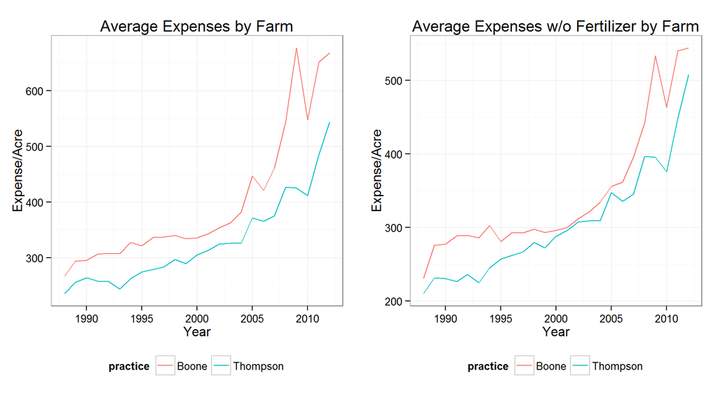

```r
theme_set(theme_bw(base_size=12))
p1<-qplot(data=df, x=year, y=mean_expense, group=practice, colour=practice, geom="line", ylab="Expense/Acre", xlab="Year", main="Average Expenses by Farm") + theme(legend.position="bottom")
p2<-qplot(data=df, x=year, y=mean_expense_nofert, group=practice, colour=practice, geom="line", ylab="Expense/Acre", xlab="Year", main="Average Expenses w/o Fertilizer by Farm") + theme(legend.position="bottom")
grid.arrange(p1,p2,ncol=2)
```

#### Profit

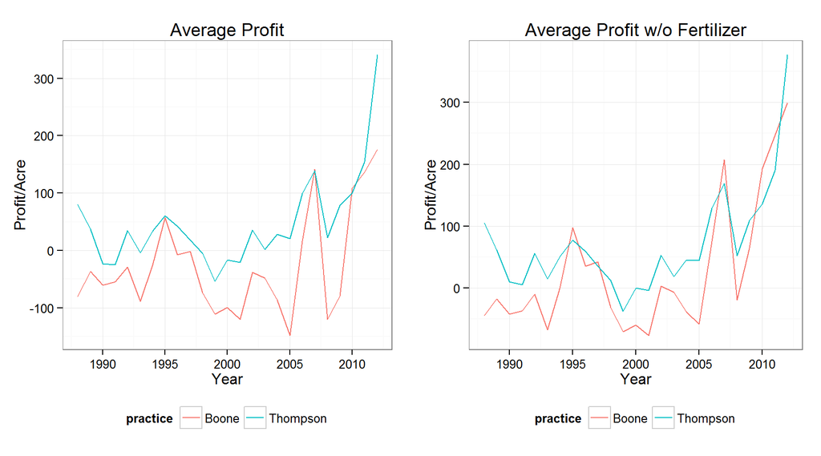

```r
p5<-qplot(data=df, x=year, y=rawprofit, group=practice, colour=practice, geom="line", ylab="Profit/Acre", xlab="Year", main="Average Profit") + theme(legend.position="bottom")
p6<-qplot(data=df, x=year, y=rawprofit_nofert, group=practice, colour=practice, geom="line", ylab="Profit/Acre", xlab="Year", main="Average Profit w/o Fertilizer") + theme(legend.position="bottom")
grid.arrange(p5,p6,ncol=2)
```

#### With/Without Fertilizer Costs – Just Corn vs SB

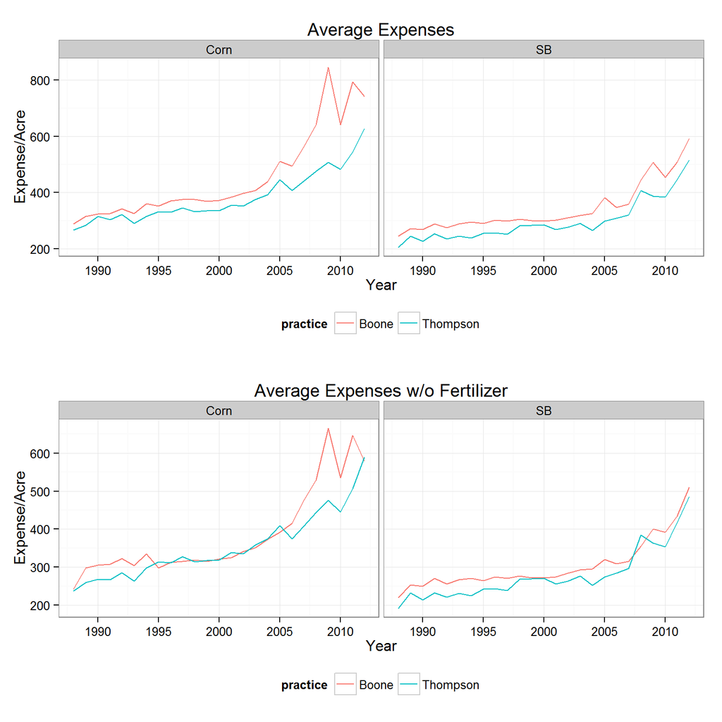

```r
p3<-qplot(data=subset(expenses, crop=="Corn" | crop=="SB"), x=year, y=expense, group=practice, colour=practice, geom="line", ylab="Expense/Acre", xlab="Year", main="Average Expenses") + facet_wrap(~crop) + theme(legend.position="bottom")
p4<-qplot(data=subset(expenses, crop=="Corn" | crop=="SB"), x=year, y=expense_nofert, group=practice, colour=practice, geom="line", ylab="Expense/Acre", xlab="Year", main="Average Expenses w/o Fertilizer") + facet_wrap(~crop) + theme(legend.position="bottom")
grid.arrange(p3,p4,ncol=1)
```

When just looking at corn, expenses for Boone drop considerably and decrease the gap between farms.

### All Additional Income and Expenses

The exploratory analysis aboves focuses on crop income, ignoring additional income from straw, stubble, and residue. However, we should also remove costs related with these income sources if we don’t include them (Purch_Pert, Manure_Charge, Windrow_Oats, Stubble_Costs, Straw_Costs).

#### Expenses

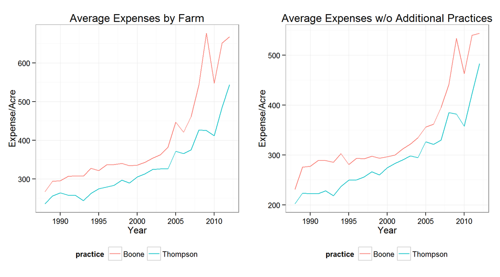

```r
p1<-qplot(data=df, x=year, y=mean_expense, group=practice, colour=practice, geom="line", ylab="Expense/Acre", xlab="Year", main="Average Expenses by Farm") + theme(legend.position="bottom")
p2<-qplot(data=df, x=year, y=mean_expense_nofert, group=practice, colour=practice, geom="line", ylab="Expense/Acre", xlab="Year", main="Average Expenses w/o Additional Practices") + theme(legend.position="bottom")
grid.arrange(p1,p2,ncol=2)
```

#### Profit

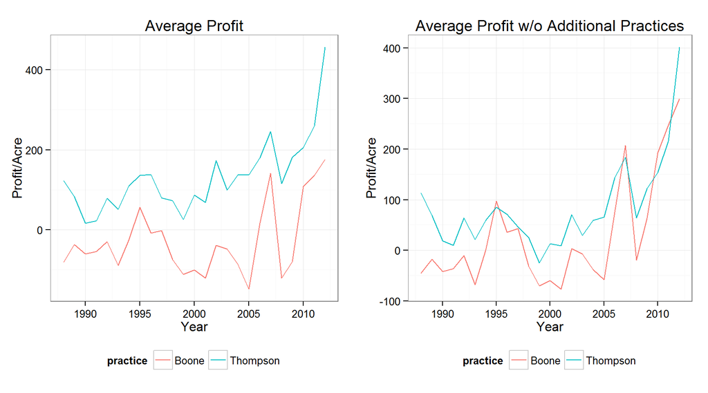

```r
p5<-qplot(data=df, x=year, y=profit_extra, group=practice, colour=practice, geom="line", ylab="Profit/Acre", xlab="Year", main="Average Profit") + theme(legend.position="bottom")
p6<-qplot(data=df, x=year, y=rawprofit_nofert, group=practice, colour=practice, geom="line", ylab="Profit/Acre", xlab="Year", main="Average Profit w/o Additional Practices") + theme(legend.position="bottom")
grid.arrange(p5,p6,ncol=2)
```

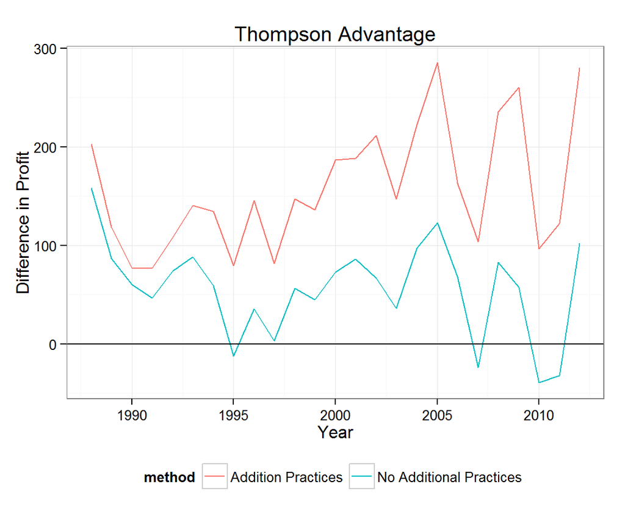

```r
diff_pextra<-subset(df, practice=="Thompson")$profit_extra - subset(df, practice=="Boone")$profit_extra
diff_pnone<-subset(df, practice=="Thompson")$rawprofit_nofert - subset(df, practice=="Boone")$rawprofit_nofert
df2<-data.frame(year=rep(unique(df$year),2), diff<-c(diff_pextra, diff_pnone), method=rep(c("Addition Practices", "No Additional Practices"), each=length(diff_pextra)))

qplot(data=df2, x=year, y=diff, group=method, colour=method, geom="line", ylab="Difference in Profit", xlab="Year", main="Thompson Advantage") + geom_hline(aes(yintercept=0)) + theme(legend.position="bottom")
```